# Total organic carbon - modelling

# Install packages

```r
rm(list=ls())

if(!require("pacman")) install.packages("pacman"); library(pacman)
p_load(here,
       terra,
       dplyr,
       caret,
       ggplot2,
       sf,
       CAST,
       lwgeom,
       geosphere,
       quantregForest,
       doParallel,
       ModelMetrics,
       forcats)
```

# Preparation

## Which sediment depth interval?

sf: 0 - 2 cm ss: 2 - 5 cm

```r
dpt <- "sf"
```

## Get date of latest OC_sf prediction

```r
date <- list.files(path = here("toc_model", "data", "final"), pattern = "OC_sf_median_")
date <- sub(".*?OC_sf_median_(.*?).tif*", "\\1", date)
date <- as.Date(date)
date <- max(date)
```

## Load required data

```r
OC <- vect(here("toc_model", "data", "interim", paste0("OC_", dpt, ".shp")))
AoI <- read_sf(here("toc_model", "data", "interim", "AoI.shp"))

predictors <- rast(here("toc_model", "data", "interim", "predictors.tif"))
if(dpt == "ss"){
  OCabove <- rast(here("toc_model", "data", "final", paste0("OC_sf_median_", date, ".tif")))
  predictors <- c(predictors, OCabove)
  names(predictors)[[length(names(predictors))]] <- "OC"
  rm(OCabove)
}

names(predictors)
```

```
 [1] "BATH"      "DIST"      "TPI25"     "TPI75"     "TPI125"    "PPmean"    "PPmax"     "CHLmean"   "CHLmax"    "SPMmean"   "SPMmax"    "pCO2min"   "pCO2mean"  "pCO2max"
[15] "pCO2range" "O2min"     "O2mean"    "O2max"     "O2range"   "SICmin"    "SICmean"   "SICmax"    "SICrange"  "UVmean"    "UVmax"     "Tmin"      "Tmean"     "Tmax"
[29] "Trange"    "Smin"      "Smean"     "Smax"      "Srange"    "sSARmin"   "sSARmean"  "sSARmax"   "sSARrange" "MUD"
```

## Create regression matrix

```r
rm_oc <- as.data.frame(terra::extract(predictors, OC, bind = TRUE))
rm_oc <- rm_oc[-1] #removes first column (ID)
rm_oc <- na.omit(rm_oc) #removes rows with NAs
summary(rm_oc)
```

```
      TOC              BATH               DIST            TPI25              TPI75              TPI125            PPmean           PPmax           CHLmean
 Min.   :0.0001   Min.   :-5527.41   Min.   :  4000   Min.   :-2691.44   Min.   :-3346.53   Min.   :-3924.0   Min.   : 192.9   Min.   : 347.5   Min.   :0.2695
 1st Qu.:0.6700   1st Qu.: -501.91   1st Qu.: 37947   1st Qu.: -138.56   1st Qu.: -304.73   1st Qu.: -357.4   1st Qu.: 332.2   1st Qu.: 822.7   1st Qu.:0.5975
 Median :1.2400   Median : -329.44   Median : 62225   Median :  -40.01   Median : -129.62   Median : -151.8   Median : 406.6   Median : 964.1   Median :0.7680
 Mean   :1.2946   Mean   : -536.72   Mean   : 92080   Mean   :  -64.60   Mean   : -123.46   Mean   : -117.9   Mean   : 451.8   Mean   :1033.1   Mean   :0.9908
 3rd Qu.:1.9450   3rd Qu.: -257.29   3rd Qu.:128561   3rd Qu.:   15.55   3rd Qu.:   88.22   3rd Qu.:  155.2   3rd Qu.: 548.2   3rd Qu.:1191.9   3rd Qu.:1.2784
 Max.   :3.6000   Max.   :  -56.06   Max.   :408490   Max.   :  943.06   Max.   :  844.16   Max.   : 1083.1   Max.   :1224.1   Max.   :2633.3   Max.   :4.3582
     CHLmax           SPMmean           SPMmax          pCO2min         pCO2mean        pCO2max        pCO2range          O2min           O2mean          O2max
 Min.   : 0.8364   Min.   :0.5117   Min.   : 1.114   Min.   :19.72   Min.   :27.74   Min.   :30.64   Min.   : 6.018   Min.   :239.0   Min.   :280.8   Min.   :306.6
 1st Qu.: 2.4239   1st Qu.:0.6241   1st Qu.: 2.020   1st Qu.:28.95   1st Qu.:33.93   1st Qu.:37.49   1st Qu.: 8.570   1st Qu.:243.3   1st Qu.:287.9   1st Qu.:322.6
 Median : 3.5816   Median :0.6894   Median : 2.501   Median :29.93   Median :35.56   Median :39.99   Median :12.524   Median :260.1   Median :293.8   Median :336.9
 Mean   : 4.8673   Mean   :0.7621   Mean   : 3.399   Mean   :28.97   Mean   :34.91   Mean   :40.58   Mean   :11.607   Mean   :266.2   Mean   :302.2   Mean   :343.3
 3rd Qu.: 6.1006   3rd Qu.:0.7735   3rd Qu.: 3.541   3rd Qu.:30.33   3rd Qu.:36.55   3rd Qu.:43.66   3rd Qu.:13.668   3rd Qu.:281.6   3rd Qu.:309.7   3rd Qu.:366.2
 Max.   :43.7530   Max.   :3.8902   Max.   :54.967   Max.   :33.14   Max.   :39.01   Max.   :52.16   Max.   :20.714   Max.   :348.8   Max.   :371.9   Max.   :397.8
    O2range          SICmin             SICmean             SICmax            SICrange          UVmean            UVmax             Tmin             Tmean
 Min.   :280.8   Min.   :0.000e+00   Min.   :0.000000   Min.   :0.000000   Min.   :0.0000   Min.   :0.02098   Min.   :0.1062   Min.   :-2.0625   Min.   :-0.9144
 1st Qu.:287.9   1st Qu.:0.000e+00   1st Qu.:0.000000   1st Qu.:0.000000   1st Qu.:0.0000   1st Qu.:0.05783   1st Qu.:0.2487   1st Qu.:-0.5538   1st Qu.: 2.2238
 Median :293.8   Median :0.000e+00   Median :0.000000   Median :0.000000   Median :0.0000   Median :0.07328   Median :0.3075   Median : 3.8397   Median : 5.8188
 Mean   :302.2   Mean   :8.042e-05   Mean   :0.031838   Mean   :0.107864   Mean   :0.1078   Mean   :0.08219   Mean   :0.3360   Mean   : 2.7015   Mean   : 4.6089
 3rd Qu.:309.7   3rd Qu.:0.000e+00   3rd Qu.:0.001016   3rd Qu.:0.001946   3rd Qu.:0.0000   3rd Qu.:0.09728   3rd Qu.:0.3889   3rd Qu.: 5.1050   3rd Qu.: 6.8816
 Max.   :371.9   Max.   :5.455e-03   Max.   :0.684373   Max.   :0.990097   Max.   :0.9901   Max.   :0.26741   Max.   :0.9583   Max.   : 6.6931   Max.   : 9.3750
      Tmax             Trange              Smin           Smean            Smax           Srange            sSARmin          sSARmean          sSARmax
 Min.   :-0.6775   Min.   : 0.03426   Min.   :32.11   Min.   :34.09   Min.   :34.66   Min.   :0.002834   Min.   :0.0000   Min.   : 0.0000   Min.   : 0.000
 1st Qu.: 4.6938   1st Qu.: 2.42183   1st Qu.:34.83   1st Qu.:34.95   1st Qu.:35.05   1st Qu.:0.150261   1st Qu.:0.0000   1st Qu.: 0.0000   1st Qu.: 0.000
 Median : 7.3957   Median : 3.60003   Median :34.92   Median :35.05   Median :35.23   Median :0.263927   Median :0.0000   Median : 0.0000   Median : 0.000
 Mean   : 6.6859   Mean   : 3.98442   Mean   :34.88   Mean   :35.08   Mean   :35.21   Mean   :0.323509   Mean   :0.2371   Mean   : 0.6333   Mean   : 1.262
 3rd Qu.: 8.8964   3rd Qu.: 5.12844   3rd Qu.:35.02   3rd Qu.:35.26   3rd Qu.:35.36   3rd Qu.:0.397102   3rd Qu.:0.0000   3rd Qu.: 0.3046   3rd Qu.: 1.085
 Max.   :17.0024   Max.   :13.69696   Max.   :35.23   Max.   :35.31   Max.   :37.22   Max.   :3.082333   Max.   :8.6229   Max.   :12.3835   Max.   :17.806
   sSARrange           MUD
 Min.   : 0.000   Min.   :0.001671
 1st Qu.: 0.000   1st Qu.:0.505665
 Median : 0.000   Median :0.775569
 Mean   : 1.024   Mean   :0.704554
 3rd Qu.: 1.053   3rd Qu.:0.979447
 Max.   :13.241   Max.   :0.999976
```

## Type of response?

Define which property is used as response data.

```r
resp_type <- "TOC"
resp_unit <- "weight-%"
```

# Quantile Regression Forest model

## Distances in environmental space

Distances in environmental (feature) space are computed.

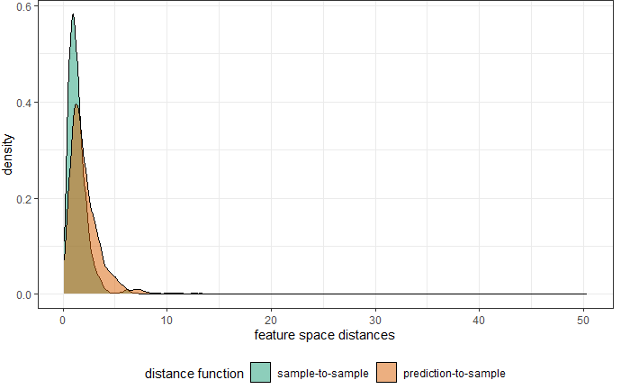

```r
dist_env <- geodist(st_as_sf(OC),
                    predictors,
                    type = "feature"
                     )

plot(dist_env)
```

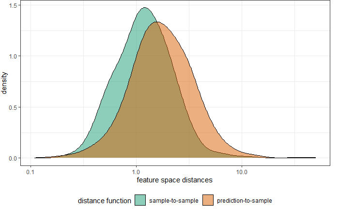

```r
plot(dist_env) + scale_x_log10()
```

## Distances in geographic space

Distances in geographic space are computed.

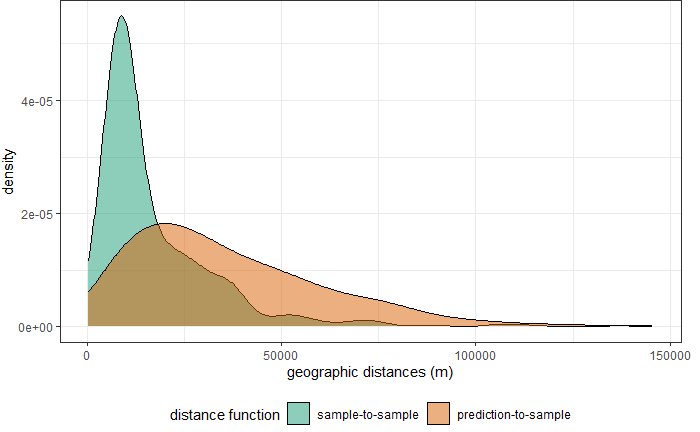

```r
dist_geogr <- geodist(st_as_sf(OC),
                     predictors,
                     type = "geo"
                     )

plot(dist_geogr)
```

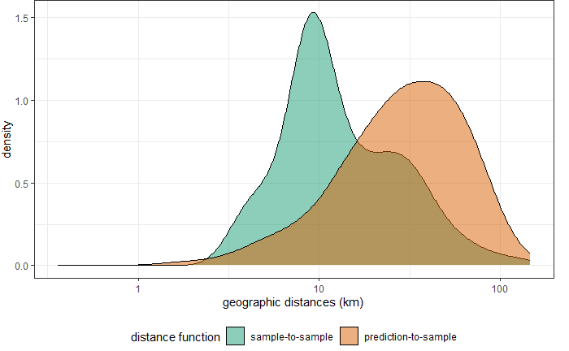

```r
plot(dist_geogr, unit="km") + scale_x_log10()
```

## Creating spatial blocks

Spatial blocks and folds are created. The folds will be used in a spatial k-fold cross validation. The k-fold nearest neighbour distance matching algorithm is used here.

```r
OC <- project(OC, AoI)
k <- 10 # Number of folds
knndmfolds <- knndm(tpoints = st_as_sf(OC),
                    modeldomain = AoI,
                    k = k,
                    samplesize = 2000)
```

```
2000 prediction points are sampled from the modeldomain
```

## Distances in geographic space including CV distances

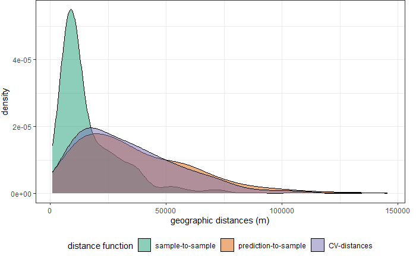

```r
dist_geogr2 <- geodist(st_as_sf(OC),
                       predictors,
                       cvfolds= knndmfolds$indx_test,
                       type = "geo"
                       )

plot(dist_geogr2)
```

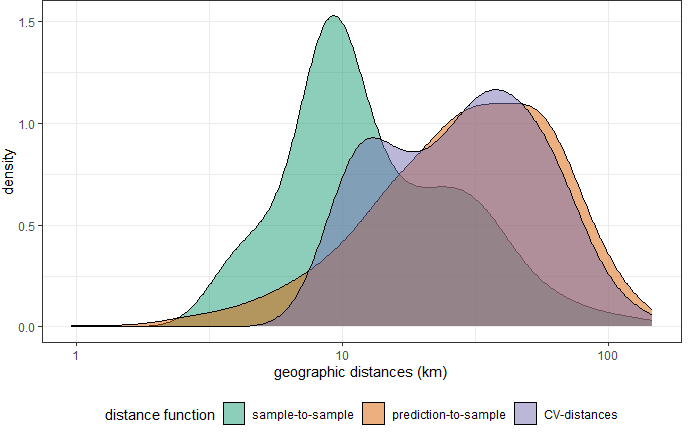

```r
plot(dist_geogr2, unit="km") + scale_x_log10()
```

## Model tuning

A Quantile Regression Forest model is tuned. Predictor variables are selected in a forward feature selection approach and various values of the mtry parameter are tested in a spatial k-fold cross validation.

The maximum number of iterations to be performed can be calculated upfront, based on the number of pre-selected predictors:

```r
factorial(length(names(predictors)))/(factorial(2)*factorial(length(names(predictors))-2)) + sum(c((length(names(predictors))-2):1))
```

```
[1] 1369
```

### Forward feature selection

The best combination of predictor variables (features) is found in a forward feature selection process.

```r
model
```

```
Selected Variables:
O2max MUD Tmean BATH PPmean TPI125 pCO2max
---
Quantile Random Forest

685 samples
  7 predictor

No pre-processing
Resampling: Cross-Validated (10 fold)
Summary of sample sizes: 595, 629, 626, 617, 624, 631, ...
Resampling results across tuning parameters:

  mtry  RMSE       Rsquared   MAE
  2     0.3101011  0.7985445  0.2123887
  4     0.3189632  0.7855124  0.2194446
  7     0.3279118  0.7749246  0.2256987

Rsquared was used to select the optimal model using the largest value.
The final value used for the model was mtry = 2.
```

### FFS plot

Plot of R2 over the model runs.

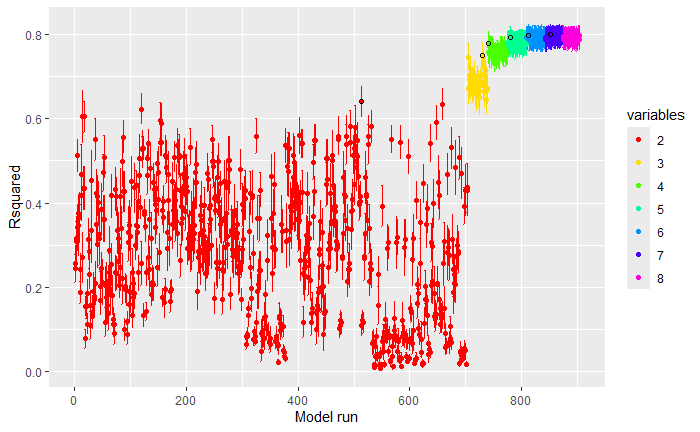

```r
plot(model)
```

## Validation statistics

The validation results of the optimal RF model.

Note that these are the statistics based on the predicted values of the selected model. These differ from the values from the tuning (above), which are the means of the k predictions based on the folds.

```r
t <- data.frame(model$pred$pred, model$pred$obs)

validation <- data.frame(mse=numeric(), rmse=numeric(), r2=numeric())
validation[1,1] <- round(sum(t$model.pred.obs - t$model.pred.pred)/nrow(t), 3)
validation[1,2] <- round(rmse(t$model.pred.obs, t$model.pred.pred), 3)
validation[1,3] <- round(cor(t$model.pred.obs, t$model.pred.pred)^2, 3)

colnames(validation) <- c("ME", "RMSE", "r2")
rownames(validation) <- NULL
validation
```

| ME | RMSE | r2 |
| --- | --- | --- |
| 0.012 | 0.309 | 0.814 |

## Validation plot

```r
p <-  ggplot(t, aes(x = model.pred.pred, y = model.pred.obs)) +
      geom_abline(intercept = 0, slope = 1, colour = "grey", linewidth = 1.2) +
      geom_smooth(method = "lm") +
      geom_point() +
      scale_fill_continuous(type = "viridis") +
      theme_bw() +
      scale_x_continuous(name = "Predicted value") +
      scale_y_continuous(name = "Observed value") +
      ggtitle(paste0(resp_type, " (", resp_unit, ")"))

p

jpeg(filename = here("toc_model", "figures", paste0("validation_plot_",resp_type, "_",dpt , ".jpg")), width = 15, height = 10, units = "cm", res = 300)
```

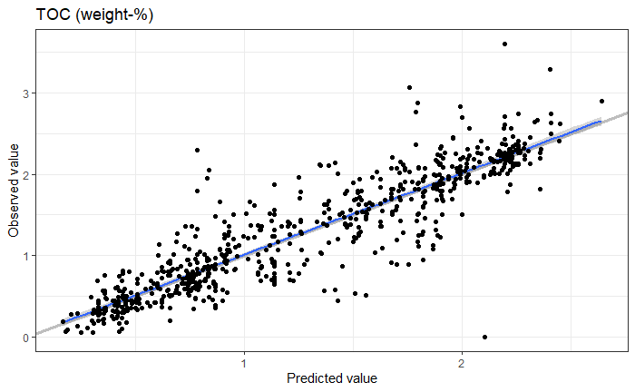

```r
p
dev.off()
```

## Variable importance

```r
imp <- varImp(model$finalModel, scale = FALSE)
imp$Predictor <- rownames(imp)
rownames(imp) <- NULL
imp <- imp[order(imp[1], decreasing = TRUE), c(2, 1)]
colnames(imp)[2] <- "IncMSE"

impfig <- imp %>%
  mutate(Predictor = fct_reorder(Predictor, IncMSE)) %>%
  ggplot( aes(x=Predictor, y=IncMSE)) +
    geom_bar(stat="identity", fill="#f68060", alpha=.6, width=.4) +
    coord_flip() +
    xlab("") +
    ylab("% increase in MSE") +
    theme_bw()

impfig

jpeg(filename = here("toc_model", "figures", paste0("variable_importance_plot_",resp_type, "_",dpt , ".jpg")), width = 10, height = 10, units = "cm", res = 300)
```

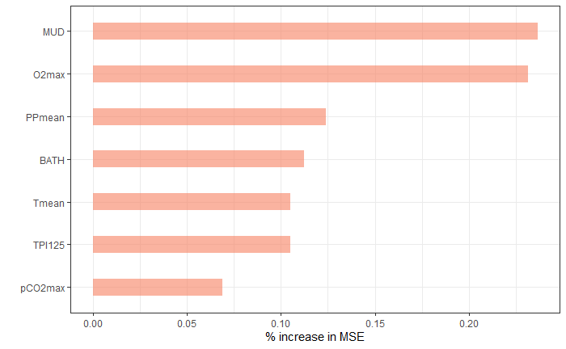

```r
impfig
dev.off()
```

## Distances in environmental space including CV distances

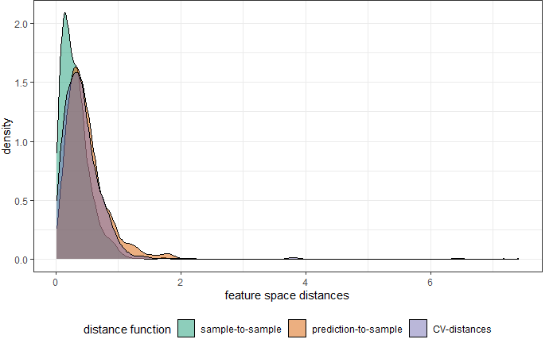

```r
dist_env2 <- geodist(st_as_sf(OC),
                     predictors,
                     type = "feature",
                     cvfolds= knndmfolds$indx_test,
                     variables = sel_preds
                     )

plot(dist_env2)
```

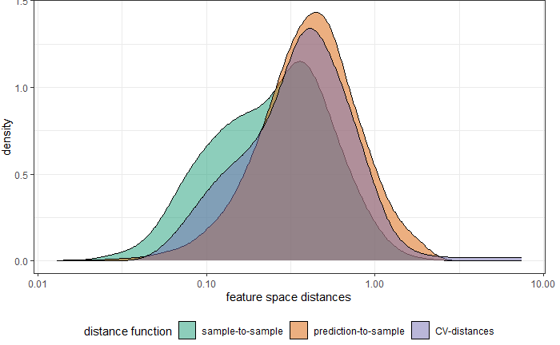

```r
plot(dist_env2) + scale_x_log10()
```

## Partial dependence

Partial dependence plots give a graphical depiction of the marginal effect of a variable on the response.

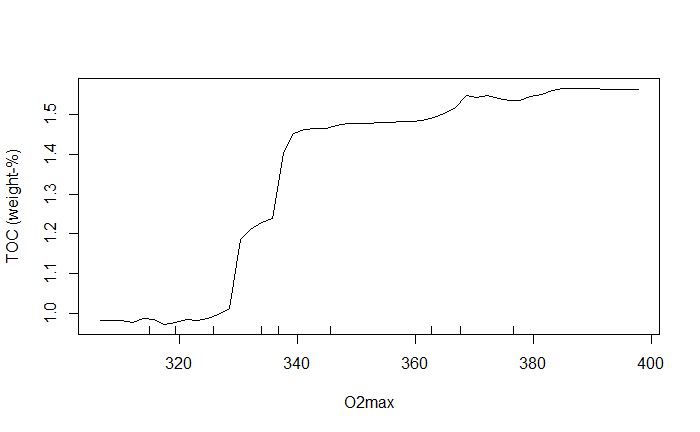

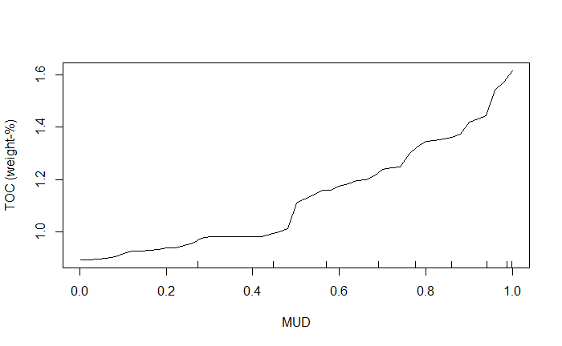

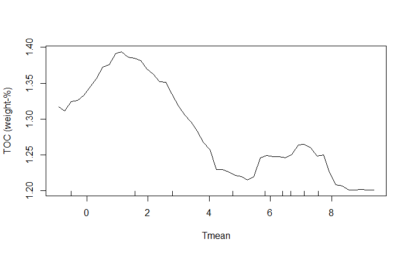

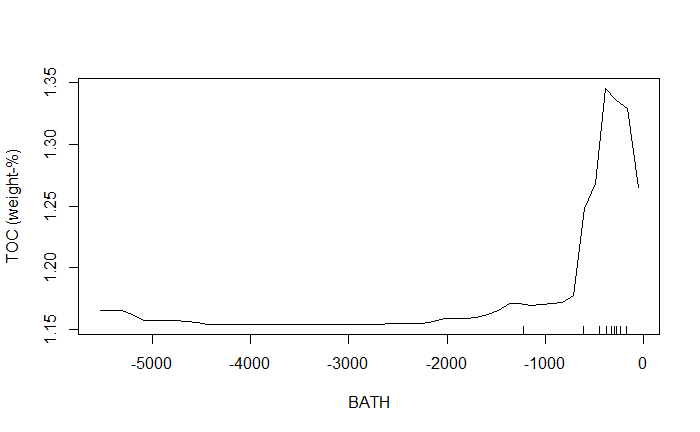

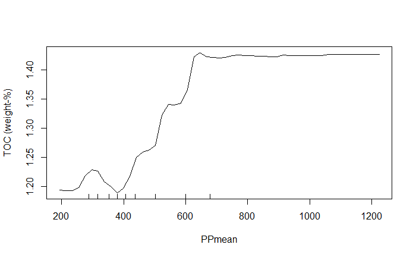

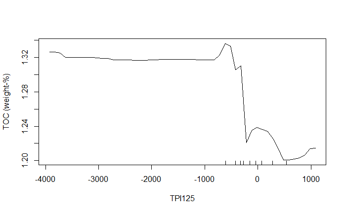

```r
m2 <- model$finalModel
class(m2) <- "randomForest"

for (i in 1:length(sel_preds)) {
  partialPlot(x = m2, pred.data = rm_oc, x.var = sel_preds[i], main = "", xlab = sel_preds[i], ylab = paste0(resp_type, " (", resp_unit, ")"))
}
```

[figure not shown]

```r
NA
```

# Predict QRF model

## Predict OC

OC is predicted. Median values of the QRF distribution are calculated as central values. The 90% prediction interval and the prediction interval ratio are calculated as measures of uncertainty.

```r
preds <- raster::stack(predictors[[sel_preds]])
OC_med <- predict(preds, model$finalModel, what = 0.5)
OC_p95 <- predict(preds, model$finalModel, what = 0.95)
OC_p5 <- predict(preds, model$finalModel, what = 0.05)
OC_pi90 <- OC_p95 - OC_p5
OC_pir <- OC_pi90 / OC_med
```

## Area of applicability

```r
OC_trainDI <- trainDI(model = model,
                        variables = sel_preds)
```

```
Computing DI of training data...
```

```r
print(OC_trainDI)
```

```
DI of 685 observation
Predictors: O2max MUD Tmean BATH PPmean TPI125 pCO2max

AOA Threshold: 0.2813561
```

```r
OC_aoa <- aoa(newdata = predictors,
                model = model,
                trainDI = OC_trainDI,
                variables = sel_preds,
)
```

```
Computing DI of new data...
Computing AOA...
Finished!
```

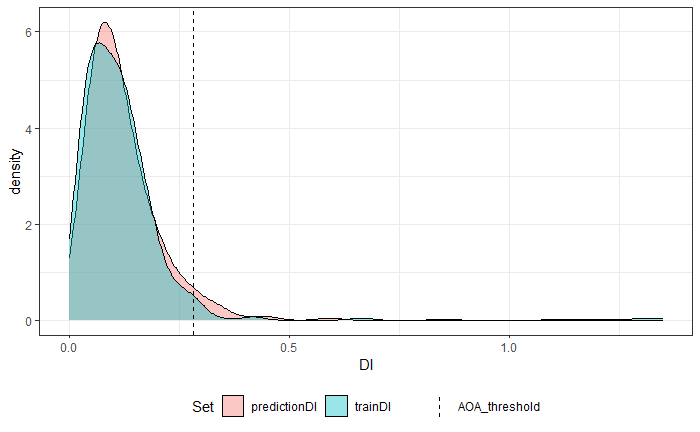

```r
plot(OC_aoa)
```

```r
fr <- freq(OC_aoa$AOA)
print(paste0("AOA = ", round(100*fr$count[2]/ sum(fr$count),2), "% of pixels"))
```

```
[1] "AOA = 95.67% of pixels"
```

## Plot results

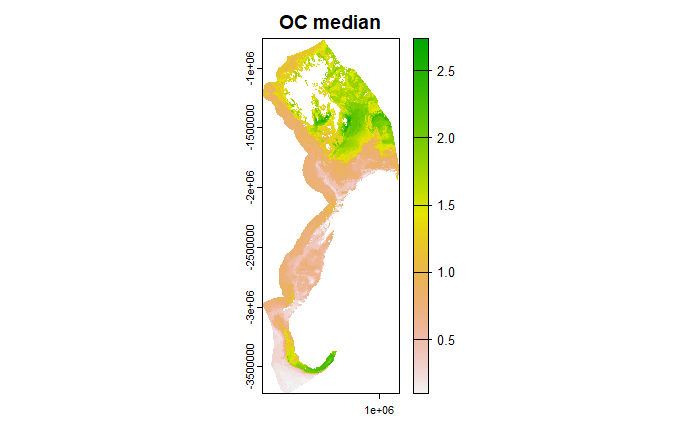

```r
plot(rast(OC_med), main = "OC median")
```

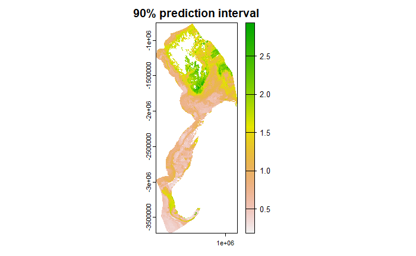

```r
plot(rast(OC_pi90), main = "90% prediction interval")
```

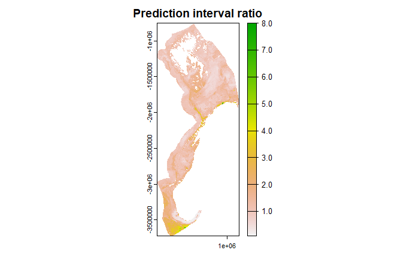

```r
plot(rast(OC_pir), main = "Prediction interval ratio")
```

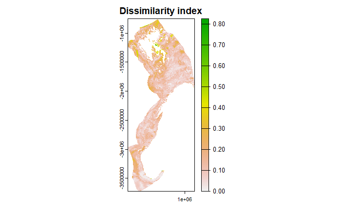

```r
plot(OC_aoa$DI, main = "Dissimilarity index")
```

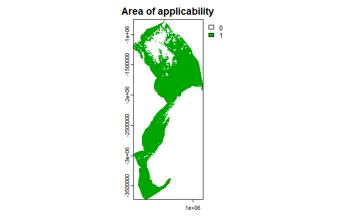

```r
plot(OC_aoa$AOA, main = "Area of applicability")
```

## Convert AOA from raster to polygon

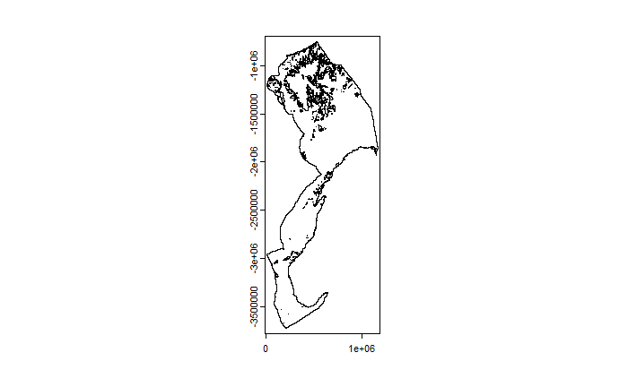

```r
aoa_poly <- as.polygons(OC_aoa$AOA, dissolve = TRUE)
plot(aoa_poly)
```

```r
write_sf(st_as_sf(aoa_poly), dsn = here("toc_model", "data", "final"), layer = paste0("OC_", dpt, "_AOA_", Sys.Date()), driver = "ESRI Shapefile")
```

## Export results

```r
writeRaster(OC_med, paste0(here("toc_model", "data", "final"), "/OC_", dpt, "_median_", Sys.Date(), ".tif"))
writeRaster(OC_p5, paste0(here("toc_model", "data", "final"), "/OC_", dpt, "_P5_", Sys.Date(), ".tif"))
writeRaster(OC_p95, paste0(here("toc_model", "data", "final"), "/OC_", dpt, "_P95_", Sys.Date(), ".tif"))
writeRaster(OC_pi90, paste0(here("toc_model", "data", "final"), "/OC_", dpt, "_PI90_", Sys.Date(), ".tif"))
writeRaster(OC_pir, paste0(here("toc_model", "data", "final"), "/OC_", dpt,  "_PIR_", Sys.Date(), ".tif"))
writeRaster(OC_aoa$DI, paste0(here("toc_model", "data", "final"), "/OC_", dpt, "_DI_", Sys.Date(), ".tif"))
writeRaster(OC_aoa$AOA, paste0(here("toc_model", "data", "final"), "/OC_", dpt, "_AOA_", Sys.Date(), ".tif"))
```

## Output a log file

```r
sink(file = paste0(here("toc_model", "data", "final", paste0("ModelLog_OC_", dpt, "_")), Sys.Date(), ".txt"))
model
print("Final Model")
paste0("ME = ", validation[1,1])
paste0("RMSE = ", validation[1,2])
paste0("R2 = ", validation[1,3])
paste0("AOA = ", round(100*fr$count[2]/ sum(fr$count),2), "% of pixels")
sink()
```